# Advanced Static Cartography in R — Exercises with Solutions (Sessions 10–12)

2026-09-27

## Required packages

```r
library(tmap)
library(tmap.networks)
library(sfnetworks)
library(tidygraph)
library(tmaptools)
library(ggplot2)
library(sf)
library(dplyr)
```

> **Datasets used** — from the `tmap` and `sfnetworks` packages, plus the commuting data of session 11 (`data/`). Exercise 3 downloads basemap tiles (internet connection required).

> | Object | Rows | Type | Key variables |
> | --- | --- | --- | --- |
> | `NLD_prov` | 12 | polygon | `name` |
> | `NLD_muni` | 345 | polygon | `name`, `population`, `dwelling_value`, `urbanity` |
> | `NLD_dist` | 3340 | polygon | same variables as `NLD_muni`, district level |
> | `roxel` | 851 | line | `type` (road type) |

# Exercise 1 — Insets (session 10)

1. Make a choropleth of the average dwelling value (`"dwelling_value"`) at district level (`NLD_dist`), without district borders, and with municipality borders.

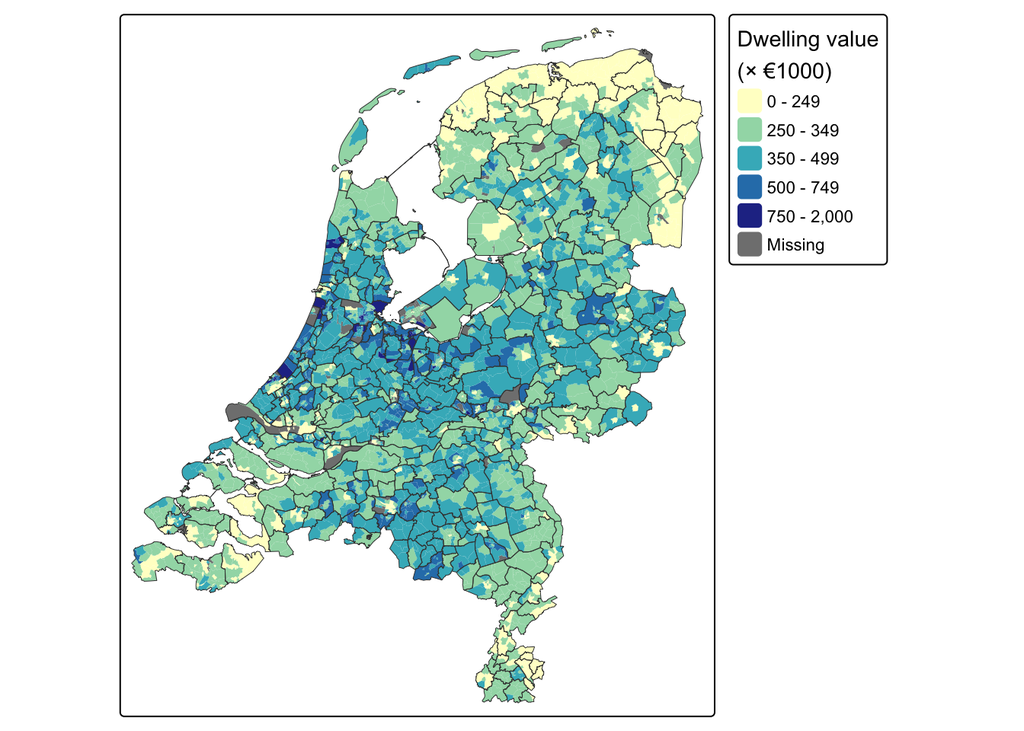

```r
tm_dv = tm_shape(NLD_dist) +
  tm_polygons(
    fill = "dwelling_value",
    fill.scale = tm_scale_intervals(
      breaks = c(0, 250, 350, 500, 750, 2000),
      values = "brewer.yl_gn_bu"),
    fill.legend = tm_legend("Dwelling value\n(× €1000)"),
    col = NULL) +
tm_shape(NLD_muni) +
  tm_borders(lwd = 0.5)
tm_dv
```

2. The districts of the city of Rotterdam are hardly visible. Add an inset map that zooms in on Rotterdam (`tmaptools::bb()`), with a box frame in the main map in the same color as the frame of the inset.

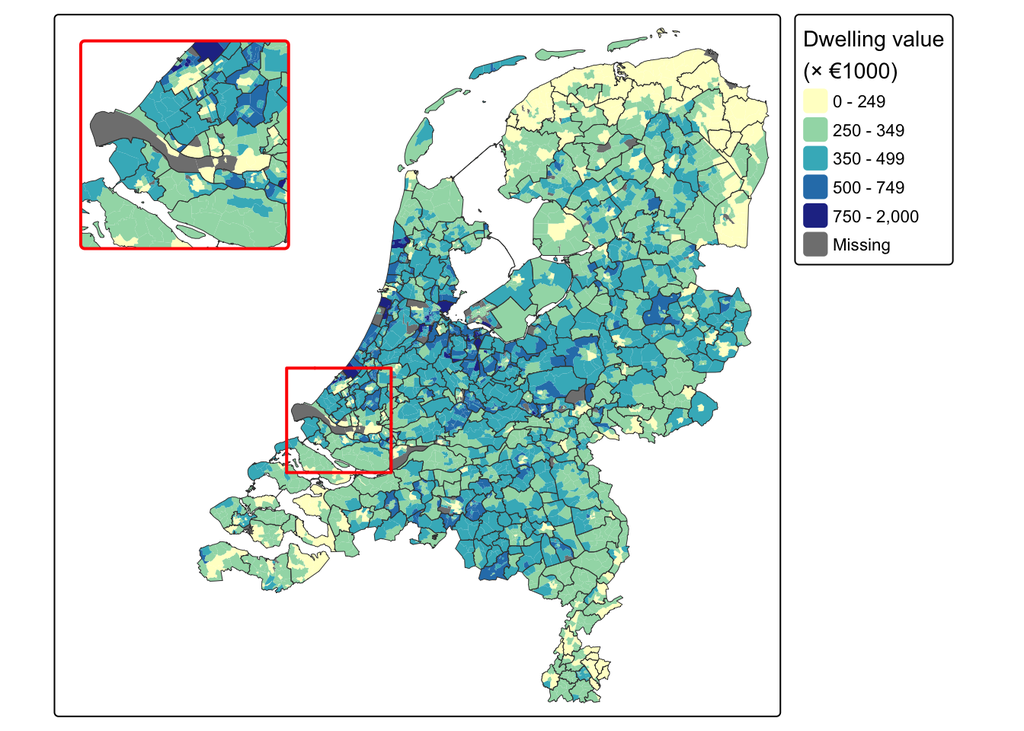

```r
bb_rot = bb(NLD_muni[NLD_muni$name == "Rotterdam", ], ext = 1.1)

tm_dv +
  tm_inset(bb_rot, position = c("left", "top"),
    box_frame.color = "red", main_frame.color = "red") +
  tm_layout(inner.margins = c(0.02, 0.25, 0.02, 0.02))
```

3. Add a ggplot2 chart as a second inset: a boxplot of `"dwelling_value"` per urbanity class (`"urbanity"`) of the municipalities. Group the legend and the chart with `group_id` and place them outside the map on the right.

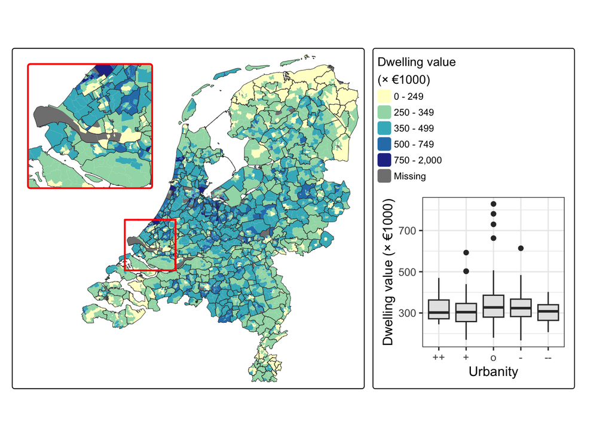

```r
g = ggplot(NLD_muni, aes(x = urbanity, y = dwelling_value)) +
  geom_boxplot(fill = "grey90") +
  scale_x_discrete("Urbanity", labels = c("++", "+", "o", "-", "--")) +
  scale_y_continuous("Dwelling value (× €1000)") +
  theme_bw()

tm_shape(NLD_dist) +
  tm_polygons(
    fill = "dwelling_value",
    fill.scale = tm_scale_intervals(
      breaks = c(0, 250, 350, 500, 750, 2000),
      values = "brewer.yl_gn_bu"),
    fill.legend = tm_legend("Dwelling value\n(× €1000)", group_id = "right"),
    col = NULL) +
tm_shape(NLD_muni) +
  tm_borders(lwd = 0.5) +
tm_inset(bb_rot, position = c("left", "top"),
  box_frame.color = "red", main_frame.color = "red") +
tm_inset(g, group_id = "right", height = 12, width = 12) +
tm_components("right", position = tm_pos_out("right", "center")) +
tm_layout(inner.margins = c(0.02, 0.25, 0.02, 0.02))
```

# Exercise 2 — Networks (session 11)

1. Convert the `roxel` road data (from **sfnetworks**) to an `sfnetwork` and plot the edges, colored by road type (`"type"`), and the nodes.

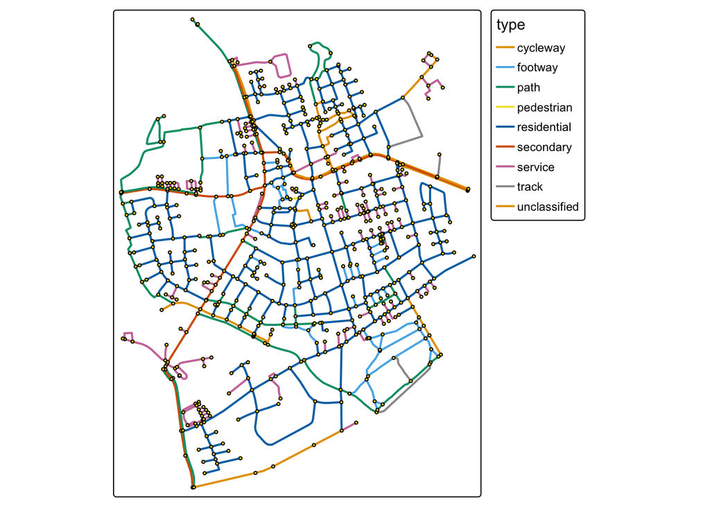

```r
sfn = as_sfnetwork(roxel)

tm_shape(sfn) +
  tm_edges(col = "type", lwd = 2) +
  tm_nodes(size = 0.2)
```

2. Which roads are important in the network? Compute the betweenness centrality of the edges with tidygraph (`centrality_edge_betweenness()`) and show it as line width. Make the road type colors subordinate (or remove them).

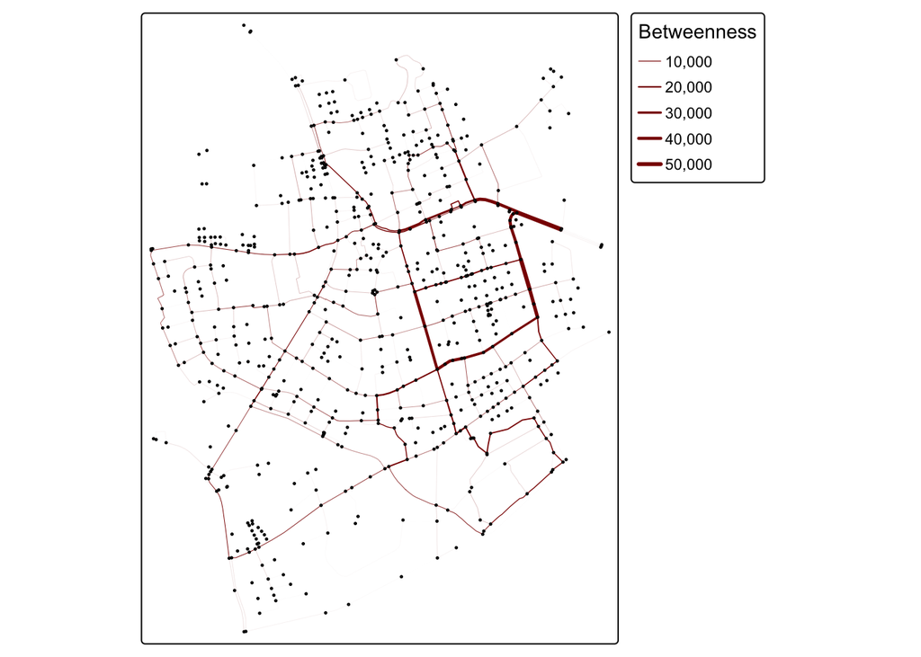

```r
sfn2 = sfn |>
  activate("edges") |>
  mutate(betweenness = centrality_edge_betweenness())

tm_shape(sfn2) +
  tm_edges(
    lwd = "betweenness",
    col = "darkred",
    lwd.scale = tm_scale_continuous(values.scale = 3),
    lwd.legend = tm_legend("Betweenness")) +
  tm_nodes(size = 0.1, fill = "grey50")
```

3. Load the commuting data from session 11 and make a flow map of the commuters to the province of Utrecht (only flows of at least 1000 commuters, no self-flows). Use half lines to show the direction.

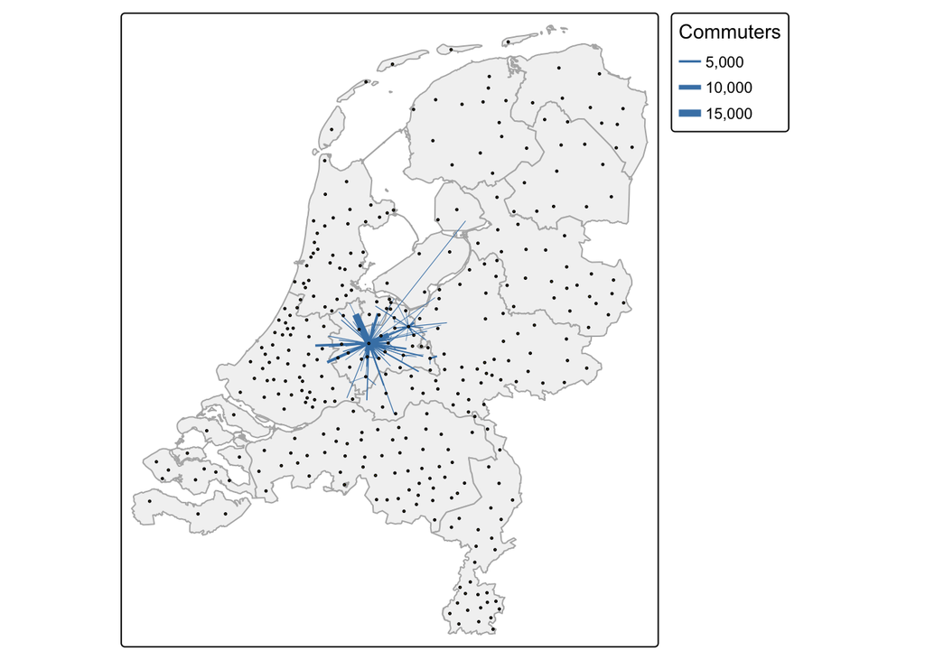

```r
od = read.csv2("data/NL_commuter_OD_2024.csv")
muni = read.csv2("data/NL_municipality_centroids_2024.csv") |>
  st_as_sf(coords = c("POINT_X", "POINT_Y"), crs = 28992)

ut_codes = muni$code[st_intersects(muni, NLD_prov[NLD_prov$name == "Utrecht", ] |>
  st_transform(28992), sparse = FALSE)[, 1]]

edges = od |>
  filter(from != to, jobs >= 1000, to %in% ut_codes) |>
  mutate(from = match(from, muni$code),
         to   = match(to,   muni$code))

net = sfnetwork(nodes = muni, edges = edges, directed = TRUE, edges_as_lines = TRUE)

tm_shape(NLD_prov) +
  tm_polygons("grey95", col = "grey70") +
tm_shape(net) +
  tm_edges(
    lwd = "jobs",
    col = "steelblue",
    from = 0.5,
    lineend = "butt",
    lwd.scale = tm_scale_continuous(values.scale = 5),
    lwd.legend = tm_legend("Commuters")) +
  tm_nodes(size = 0.1)
```

# Exercise 3 — Basemaps and final map (session 12)

1. Make a bubble map of the population of the districts of Utrecht (city) (`NLD_dist`, zoomed in with `bbox`), with bubble fill color for `"dwelling_value"`. Compare three basemaps, e.g. `"OpenStreetMap"`, `"Esri.WorldTopoMap"` and `"Esri.WorldGrayCanvas"`. Which one supports the message best?

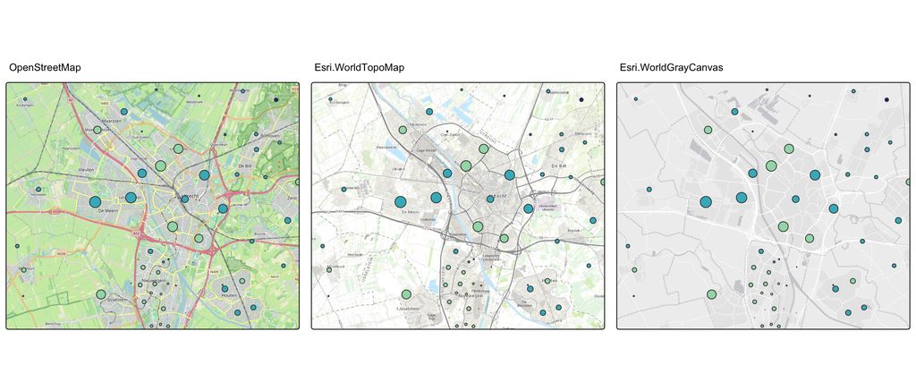

```r
bb_utr = bb(NLD_muni[NLD_muni$name == "Utrecht", ], ext = 1.3)

tm_b = function(server) {
  tm_shape(NLD_dist, bbox = bb_utr) +
    tm_bubbles(size = "population", fill = "dwelling_value",
      fill.scale = tm_scale_intervals(
        breaks = c(0, 250, 350, 500, 750, 2000),
        values = "brewer.yl_gn_bu"),
      fill.legend = tm_legend_hide(), size.legend = tm_legend_hide()) +
  tm_basemap(server) +
  tm_title(server, bg = TRUE, bg.color = "white", size = 0.8)
}
tmap_arrange(tm_b("OpenStreetMap"), tm_b("Esri.WorldTopoMap"),
             tm_b("Esri.WorldGrayCanvas"), ncol = 3, asp = NULL)
```

2. Make a choropleth of `"dwelling_value"` for the same area on top of `"Esri.WorldTopoMap"`, once with `blend = "over"` (default) and once with `blend = "multiply"`. What is the difference?

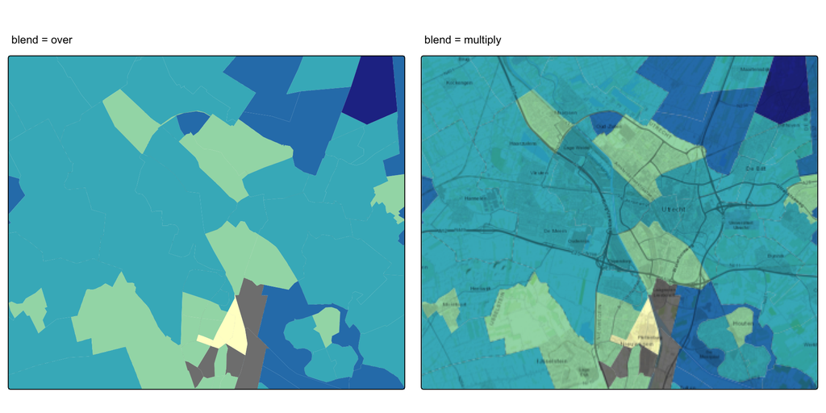

```r
tm_choro = function(blend) {
  tm_basemap("Esri.WorldTopoMap") +
  tm_shape(NLD_dist, bbox = bb_utr) +
    tm_polygons(fill = "dwelling_value",
      fill.scale = tm_scale_intervals(
        breaks = c(0, 250, 350, 500, 750, 2000),
        values = "brewer.yl_gn_bu"),
      fill.legend = tm_legend_hide(),
      col = NULL,
      blend = blend) +
  tm_title(paste("blend =", blend), bg = TRUE, bg.color = "white", size = 0.8)
}
tmap_arrange(tm_choro("over"), tm_choro("multiply"), ncol = 2, asp = NULL)
```

> **Answer:** With `"multiply"`, the roads, labels and water of the basemap stay visible through the choropleth colors.
3. Final map: choose one of the maps you made during this course (or a new one) and finish it using the checklists of session 12 (message, map type, classification, palette, projection, visual hierarchy, legend, components, credits, size). Export it with `tmap_save()`.

```r
# your own map
```